# Ch1_Hurdle SWA & VEG ~ BeaverDam

Matt Webster

2026-07-14

The purpose of this script is to explore the conditional effects of beaver dams on:

```
- surface water presence,
- surface water area,
- vegetation presence,
- vegetation area,
- and NDVI,
```

This modeling focuses solely on late summer months; August & September.

Several models are presented herein. All models have the same random effects structure for stream, year, and sample event.

```
Model 1: Surface water presence & area as a function of beaver dam presence

Model 2: Surface water presence & area as a function of beaver dam density (dams/km^2)

Model 3: Vegetation presence & area as a function of beaver dam presence

Model 4: Vegetation presence & area as a functino of beaver dam density (dams/km^2)

Model 5: NDVI as a function of beaver dam presence

Model 6: NDVI as a function of beaver dam density
```

Models 1:4 are constructed as **hurdle** models. The goal of the model in this hurdle framework is to 1) estimate the relative influence of dam presence/density on the log-odds (or probability) of surface water presence; & 2) for cases where water is present, estimate the relative influence of dam presence/density on surface water area.

## USGS Flow Data

**Data from USGS LBV Guston Coulee gage, near Saco, MT:**

**Late Summer Flow Conditions**

**2019:**

Moderate August with small peak in September

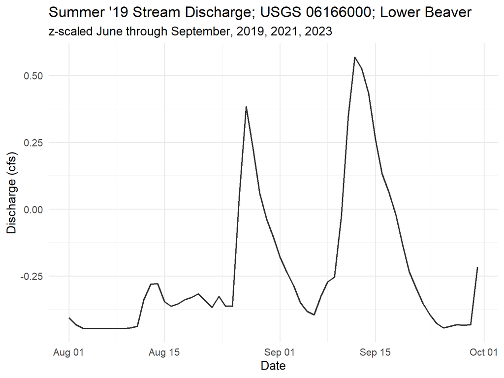

**2021:**

Low flow conditions throughout the summer season. Part of 3 year sustained drought conditions (2020, 2021, 2022).

Gage recorded no flow during August & September

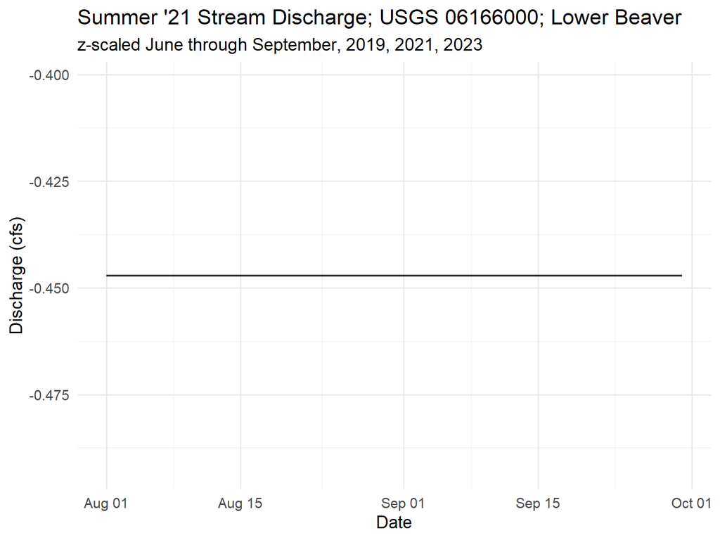

**2023:**

Moderate to low August & September flows; after early season extreme flooding.

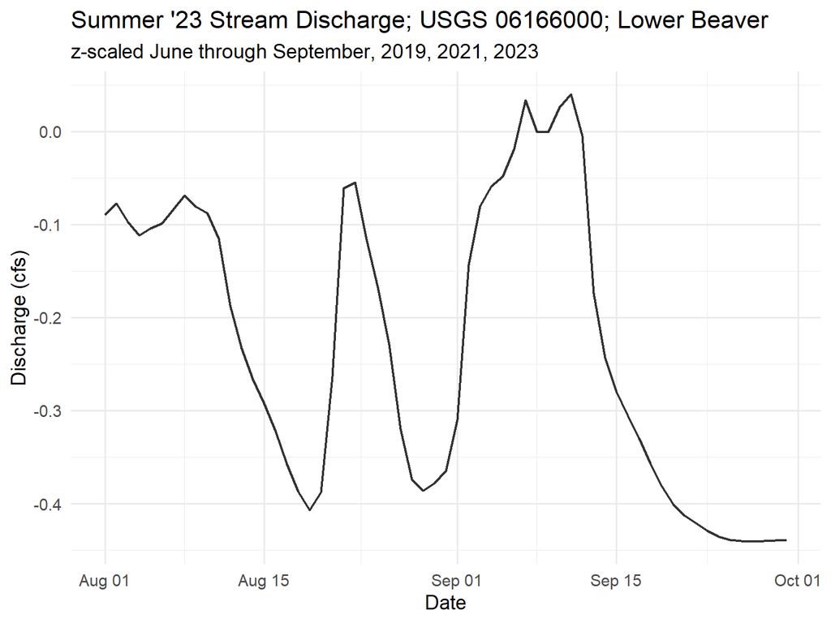

## GEE-derived data for each stream:

Currently each incoming data frame is of the following structure:

Where:

```
- clusterID_seq = dammed/undammed sample pair ID
- window_type = whether a sample window is 'dammed' or 'undammed'
- watershed = watershed identifier (e.g., "BRZ" = Brazil Ck)
- year = year
- window_length = length (m) of stream flow line within sample window
- catchment_km2 = contributing catchment area/upstream drainage area (km^2)
- riparian_area_m2 = riparian area (m^2) of sample window; 2-m vertical
  buffer from DEM low point (stream flow line)
- TO = mean topographic openness across window
- p_window: avg dam detection prob for target window; see CP Ch1
- f_window: avg dam false positive prob for target window; see CP Ch1
- beav_count_all: all unique detected dams
- beav_count_conf: unique confidently detected dams
- anthro_count: all unique detected anthropogenic dams
- isAnthro: National Wetland Inventory (NWI) "dyked/impounded"
- Nhat = estimated dam count within sample window
  - ...= beav_count_all/(p_window(1-f_window)  [McCallum 2005]
- TO_mean = mean topographic openness across window
- time_period = 2wk interval 06/01 - 09/30
- SWA = surface water area (m^2) for window during time (t)
- t = time (t) {same as time_period}
```

## Format data for hurdle:

```r
# Create binary indicator of surface water presence, for logistic part of hurdle model:
aoi_HurdleData <- aoi_glm_data_mod_refined
aoi_HurdleData$y <- ifelse(aoi_glm_data_mod_refined$SWA>0,1,0)
aoi_HurdleData$dam_km_std <- scale(aoi_HurdleData$dam_km)

# Full data indices for Bernoulli sub-model
N <- nrow(aoi_HurdleData)
y <- aoi_HurdleData$y
y2 <- aoi_HurdleData$logSWA
stream <- aoi_HurdleData$stream
year <- aoi_HurdleData$year_id
event <- aoi_HurdleData$sampleEvent_new
cluster <- aoi_HurdleData$clusterID_num
damPres <- aoi_HurdleData$damPresence
damDen <- as.numeric(aoi_HurdleData$dam_km_std)
damDen_raw <- aoi_HurdleData$dam_km

n_stream <- length(unique(aoi_HurdleData$stream))
n_year <- length(unique(aoi_HurdleData$year_id))
n_event <- length(unique(aoi_HurdleData$sampleEvent_new))
n_cluster <- length(unique(aoi_HurdleData$clusterID_num))
```

**Log-transform SWA to ‘normalize’ the right skew:**

**Visualize SWA spread:**

**Raw SWA (m^2):**

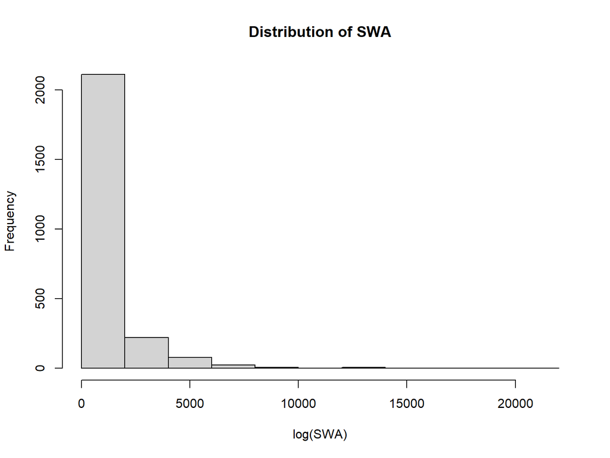

**log(SWA):**

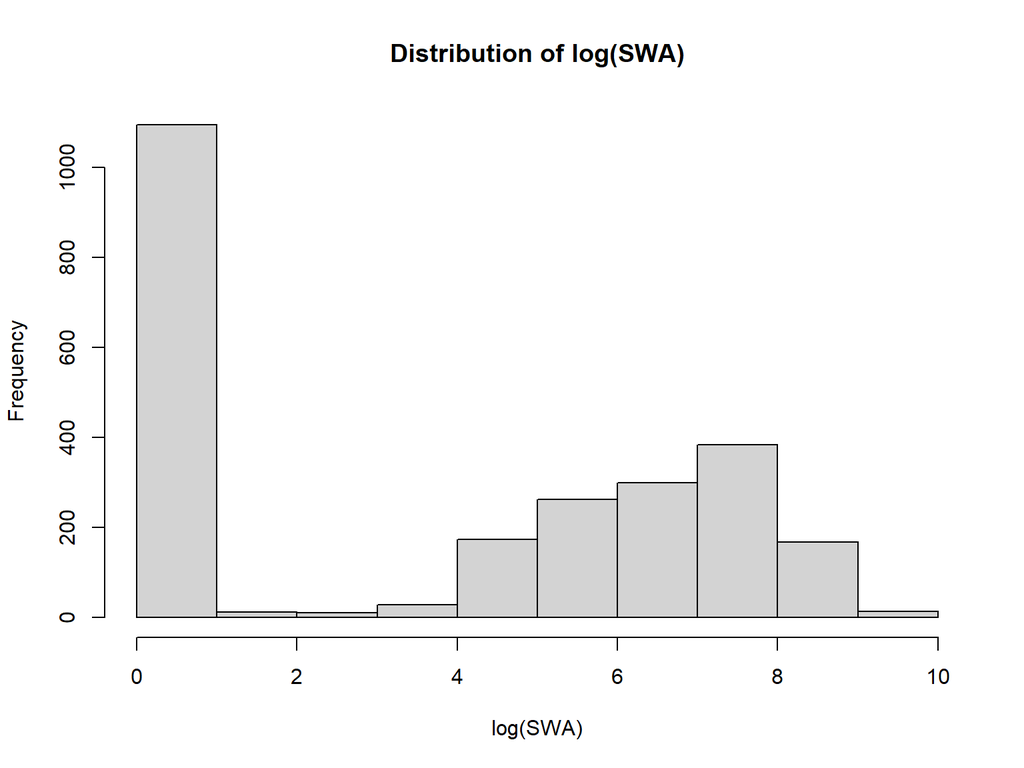

## **Hurdle HGLMM**

```
This section explores late summner SWA in relation to beaver dam presence.

Uses hurdle model with nested random slopes for beaver dam effect to allow for stream, year,
and sampleEvent to cause deviation from the global mean beaver effect.

Pt1: Surface water presence/absence; logistic regression
Pt2: Surface water amount; log(Normal) regression

Uses log(SWA) for AOI all years. Adjust priors accordingly...
```

**Model 1: SWA ~ DamPresence**

```
sink("HGLMM_hurdle_damPresence.jags")

cat("
model{
  # NEED priors and hyperpriors first so that downstream nodes can be estimated

  ##########################################################################

  # HYPERPRIORS FOR SW PRESENCE (1/2 Normal on SDs):

  sigma_zeta_stream  ~ dnorm(0,1) T(0,)
  tau_zeta_stream    <- pow(sigma_zeta_stream, -2)

  sigma_zeta_year    ~ dnorm(0,1) T(0,)
  tau_zeta_year      <- pow(sigma_zeta_year, -2)

  sigma_zeta_event   ~ dnorm(0,1) T(0,)
  tau_zeta_event     <- pow(sigma_zeta_event, -2)

  sigma_iota_stream  ~ dnorm(0,1) T(0,)
  tau_iota_stream    <- pow(sigma_iota_stream, -2)

  sigma_iota_event   ~ dnorm(0,1) T(0,)
  tau_iota_event     <- pow(sigma_iota_event, -2)

  sigma_iota_cluster ~ dnorm(0,1) T(0,)
  tau_iota_cluster   <- pow(sigma_iota_cluster, -2)

  ##########################################################################
  # HYPERPRIORS FOR SW AMOUNT (1/2 Normal on SDs):

  sigma              ~ dnorm(0,1) T(0,)
  tau                <- pow(sigma, -2)

  sigma_beta_stream  ~ dnorm(0, 0.7) T(0,)
  tau_beta_stream    <- pow(sigma_beta_stream, -2)

  sigma_beta_year    ~ dnorm(0, 0.7) T(0,)
  tau_beta_year      <- pow(sigma_beta_year, -2)

  sigma_beta_event   ~ dnorm(0, 0.7) T(0,)
  tau_beta_event     <- pow(sigma_beta_event, -2)

  sigma_eta_stream   ~ dnorm(0, 1) T(0,)
  tau_eta_stream     <- pow(sigma_eta_stream, -2)

  sigma_eta_event    ~ dnorm(0, 1) T(0,)
  tau_eta_event      <- pow(sigma_eta_event, -2)

  sigma_eta_cluster  ~ dnorm(0, 1) T(0,)
  tau_eta_cluster    <- pow(sigma_eta_cluster, -2)

  ##########################################################################
  # FIXED EFFECT PRIORS:

  # Presence/absence:
  epsilon ~ dnorm(0,0.04)
  zeta_damPres ~ dnorm(0,0.04)
  zeta_incis ~ dnorm(0,0.04)
  zeta_RIPA ~ dnorm(0,0.04)
  zeta_UDA ~ dnorm(0,0.04)

  # Amount:
  alpha ~ dnorm(0,0.04)
  beta_damPres ~ dnorm(0,0.04)
  beta_incis ~ dnorm(0,0.04)
  beta_RIPA ~ dnorm(0,0.04)
  beta_UDA ~ dnorm(0,0.04)

  ##########################################################################
  # RANDOM EFFECT PRIORS FOR SW PRESENCE:

  for(j in 1:n_stream){
    zeta_stream[j] ~ dnorm(0, tau_zeta_stream)
    iota_stream[j] ~ dnorm(0, tau_iota_stream)
  }

  for(yr in 1:n_year){
    zeta_year[yr] ~ dnorm(0, tau_zeta_year)
  }

  for(k in 1:n_event){
    zeta_event[k] ~ dnorm(0, tau_zeta_event)
    iota_event[k] ~ dnorm(0, tau_iota_event)
  }

  for(c in 1:n_cluster){
    iota_cluster[c] ~ dnorm(0, tau_iota_cluster)
  }

  ##########################################################################
  # RANDOM EFFECT PRIORS FOR SW AMOUNT:

  for(j in 1:n_stream){
    beta_stream[j] ~ dnorm(0, tau_beta_stream)
    eta_stream[j]  ~ dnorm(0, tau_eta_stream)
  }

  for(yr in 1:n_year){
    beta_year[yr] ~ dnorm(0, tau_beta_year)
  }

  for(k in 1:n_event){
    beta_event[k] ~ dnorm(beta_year[event_year[k]], tau_beta_event)
    eta_event[k]  ~ dnorm(0, tau_eta_event)
  }

  for(c in 1:n_cluster){
    eta_cluster[c] ~ dnorm(0, tau_eta_cluster)
  }

  ##########################################################################
  # DETECTION PRIORS:

  for(k in 1:n_event){
  p_TP[k] ~ dnorm(0.76, pow(0.16,-2)) T(0,1)   # empirically derived recall
  p_FP[k] ~ dnorm(0.01, pow(0.005,-2)) T(0,1)  # empirically derived FPR
  }

  ##########################################################################
  # MAIN LOOP: PRESENCE, DETECTION, AMOUNT

  for(i in 1:N){

    # Presence/absence:
    z[i] ~ dbern(psi[i])

    logit(psi[i]) <- epsilon
                     + (zeta_damPres
                        + zeta_stream[stream[i]]
                        + zeta_year[year[i]]
                        + zeta_event[event[i]]) * damPres[i]
                     + zeta_incis * incis[i]
                     + zeta_RIPA * RIPA[i]
                     + zeta_UDA * UDA[i]
                     + iota_stream[stream[i]]
                     + iota_event[event[i]]
                     + iota_cluster[cluster[i]]

    # Detection:
    p_eff[i] <- z[i] * p_TP[event[i]] + (1-z[i]) * p_FP[event[i]]
    y[i]     ~ dbern(p_eff[i])

    # Amount:
    y2[i] ~ dnorm(mu[i], tau_eff[i])

    mu[i] <- z[i] *
              (alpha
                + (beta_damPres
                  + beta_stream[stream[i]]
                  + beta_year[year[i]]
                  + beta_event[event[i]]) * damPres[i]
                + beta_incis * incis[i]
                + beta_RIPA * RIPA[i]
                + beta_UDA * UDA[i]
                + eta_stream[stream[i]]
                + eta_event[event[i]]
                + eta_cluster[cluster[i]])

    tau_eff[i] <- z[i] * tau + (1 - z[i]) * 100
  }

}
", fill = TRUE)

sink()
```

```
## [1] "2026-07-24 13:47:12 MDT"
```

```
##
## Processing function input.......
##
## Done.
##
## Beginning parallel processing using 3 cores. Console output will be suppressed.
##
## Parallel processing completed.
##
## Calculating statistics.......
##
## Done.
```

```
## [1] "2026-07-24 14:16:18 MDT"
```

## DIAGNOSTICS:

**Assess “MCMC chain health”:**

**Rubin-Gelman Rhat** – assess convergence

**Effective Sample Size** – assess posterior independence

```
## Potential scale reduction factors:
##
##                    Point est. Upper C.I.
## epsilon                  1.00       1.00
## alpha                    1.00       1.00
## zeta_damPres             1.00       1.00
## beta_damPres             1.08       1.18
## zeta_incis               1.00       1.00
## beta_incis               1.00       1.00
## zeta_RIPA                1.00       1.00
## beta_RIPA                1.00       1.00
## zeta_UDA                 1.00       1.00
## beta_UDA                 1.00       1.00
## sigma                    1.00       1.00
## sigma_zeta_stream        1.00       1.00
## sigma_iota_cluster       1.00       1.00
## p_TP[1]                  1.00       1.00
## p_FP[1]                  1.00       1.00
```

```
##            epsilon              alpha       zeta_damPres       beta_damPres
##         36795.9420         48767.5631         38768.9820           599.9775
##         zeta_incis         beta_incis          zeta_RIPA          beta_RIPA
##         17032.9449         47392.0599         45300.9842         48000.0000
##           zeta_UDA           beta_UDA              sigma  sigma_zeta_stream
##         14152.6891         48708.4228         45981.9763         15887.3154
## sigma_iota_cluster            p_TP[1]            p_FP[1]
##          9059.3709         35584.6700         48349.6793
```

```
Good Rhat values, all around 1.00.

Mostly high effective sample sizes.

Note: beta_damPres has the most trouble converging; however, Rhat near 1,
and moderate ESS for beta_damPres suggest that the parameter is still
reliably usable.
```

**Check traceplots for critical parameters**

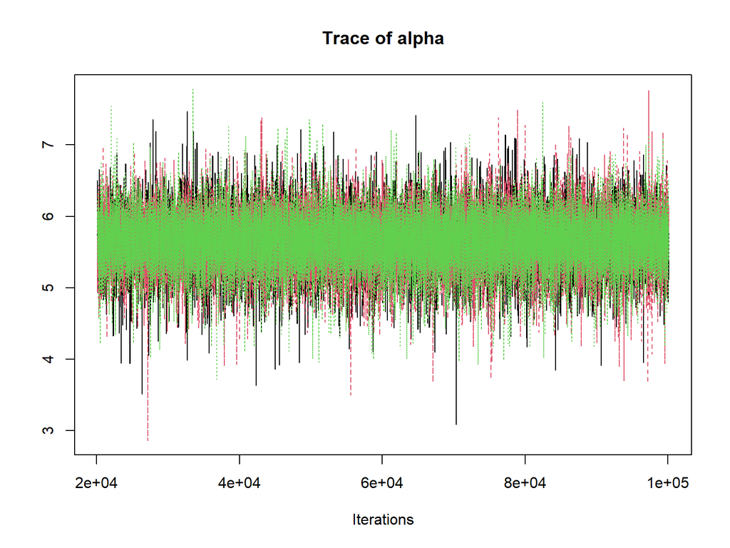

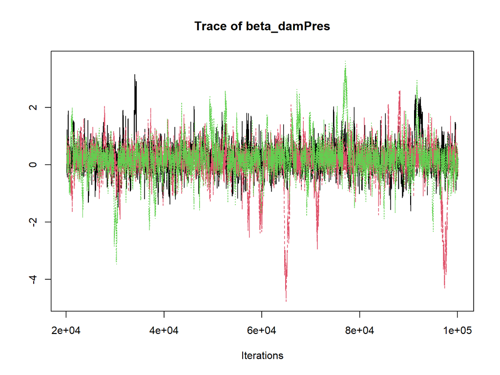

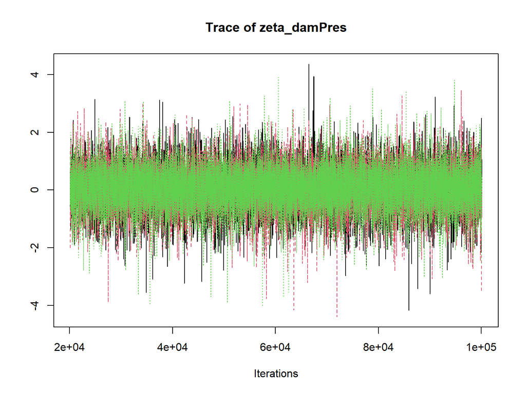

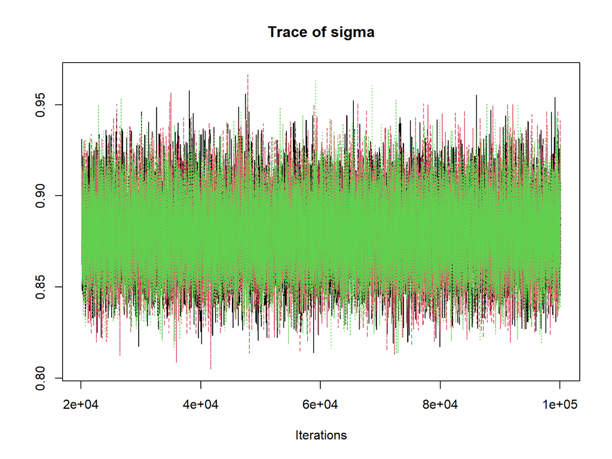

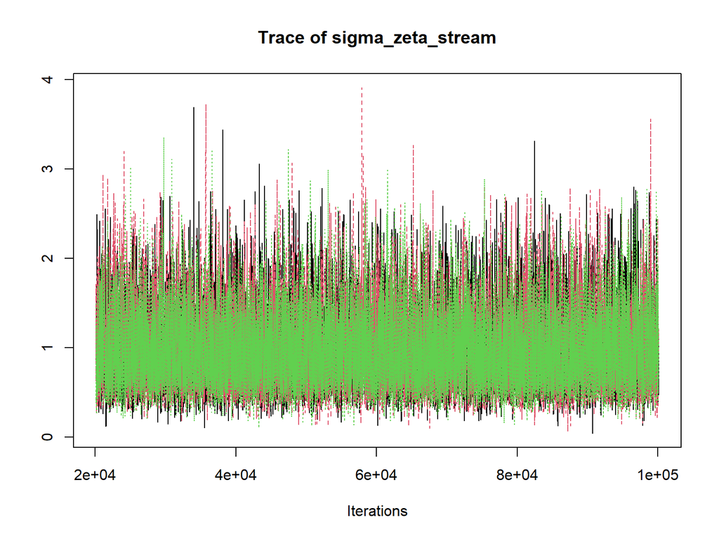

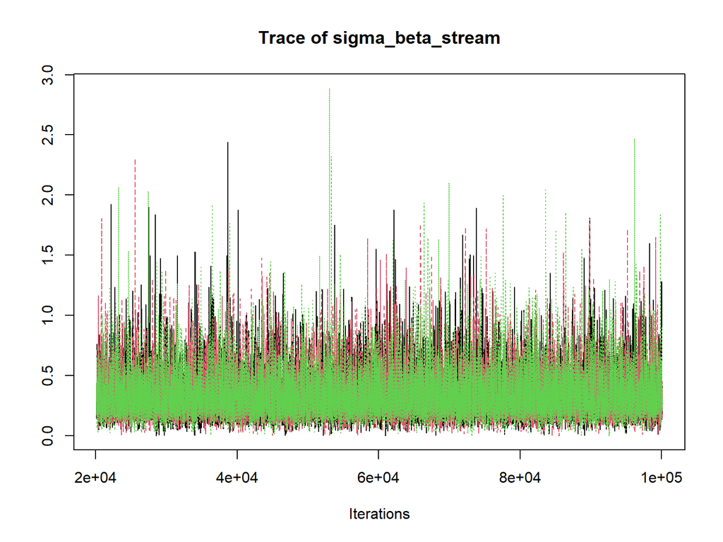

```
Traceplots are all mostly grassy. Again, see beta_damPres. REAL slow to
converge; expected, given Rhat and ESS.
```

**Posterior predictive plots:**

Predicted Psi vs observed SW Presence

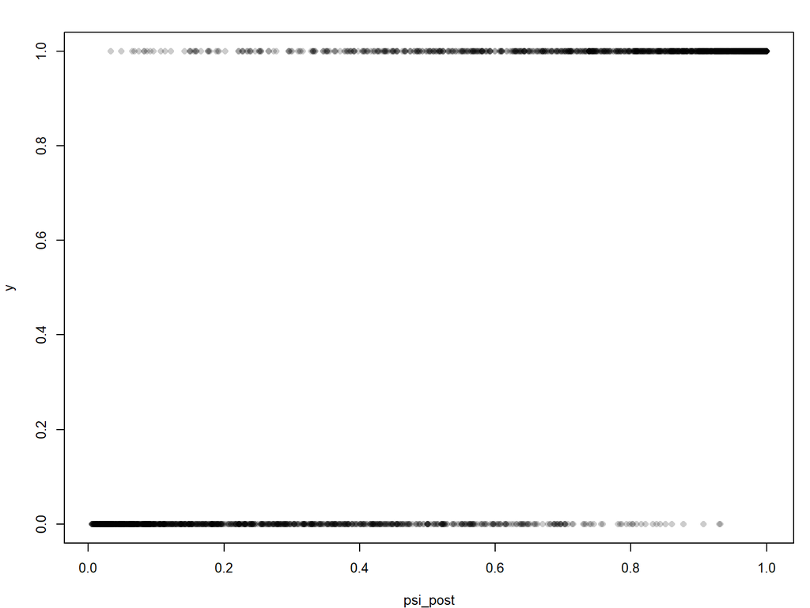

Predicted SW vs detected SW

Goal is 1:1 (ish)

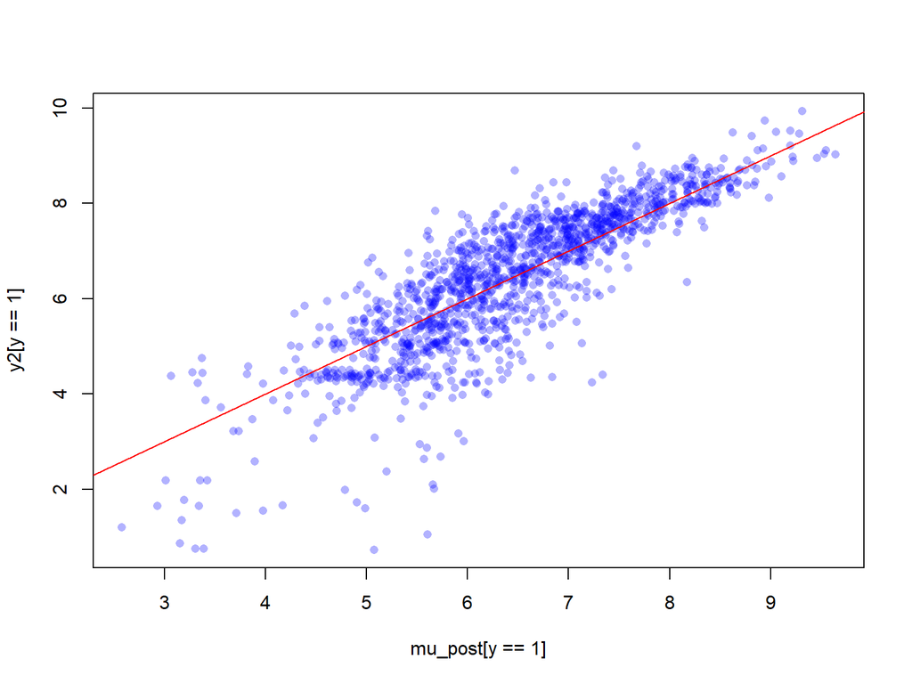

**Random effects shrinkage:**

Goal is centered around 0(ish)

1. zeta_stream; random effect of stream on sw presence
2. beta_stream; random effect of stream on sw amount
3. zeta_event; random effect of sample event on sw presence
4. beta_event; random effect of sample event on sw amount

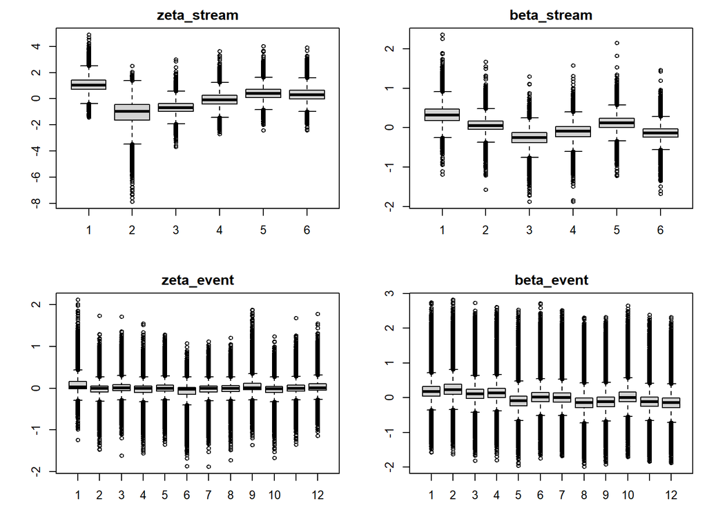

**Posterior mean dam effects:**

damPres –> swPres (logistic regression)

```
##     Min.  1st Qu.   Median     Mean  3rd Qu.     Max.
## -4.39750 -0.31308  0.08426  0.06650  0.45930  4.37707
```

```
## [1] 1.068757
```

```
Dam presence increases the odds of surface‑water presence by about 6%. On the probability scale, this corresponds to only a ~1–2 percentage‑point increase from the baseline probability, indicating that dam presence has a negligible effect on whether water is present at all.
```

Log-odds to Probability transformation:

Psi_baseline:

$$1/(1+ e^{-0.68}) = 0.664$$
Psi_dam:

$$1/(1+e^{-0.68 - 0.06}) = 1/(1+e^{-0.74})
= 0.677$$
Dam Effect on Psi:

$$Psi_{dam} - Psi_{baseline} = 0.677 -
0.664 = 0.013$$

**1.3 percetnage point increase on probability scale**

damPres –> swAmount (hglmm)

```
##     Min.  1st Qu.   Median     Mean  3rd Qu.     Max.
## -4.77652 -0.03068  0.20832  0.18734  0.44157  3.62532
```

```
## [1] 1.206034
```

```
Dam presence increases surface water area by ~ 20-25%.
```

**Prior-posterior overlap:**

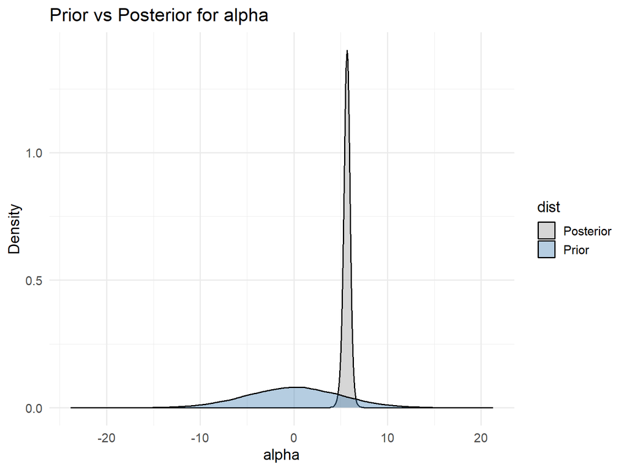

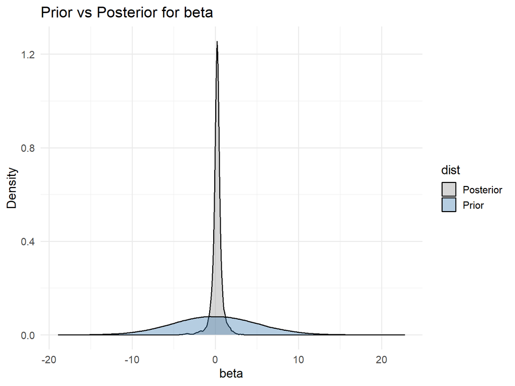

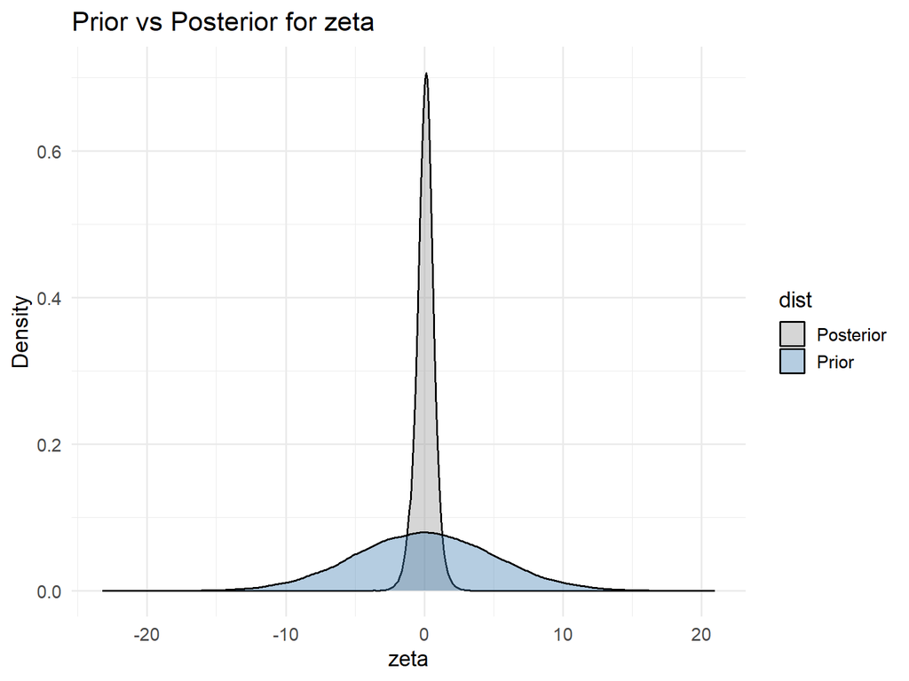

**Marginal effect** of dam presence on surface water presence, given geomorphic context.

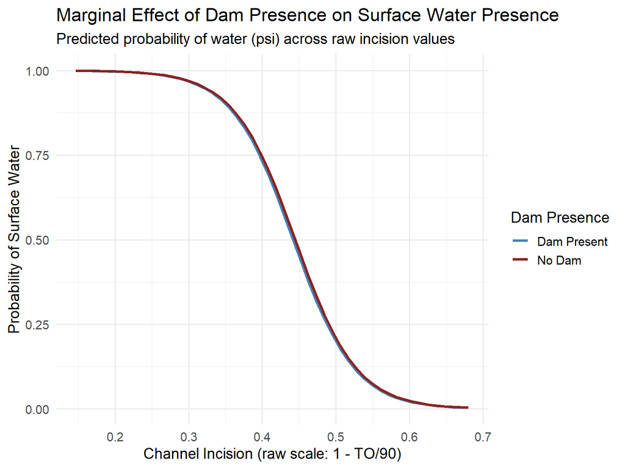

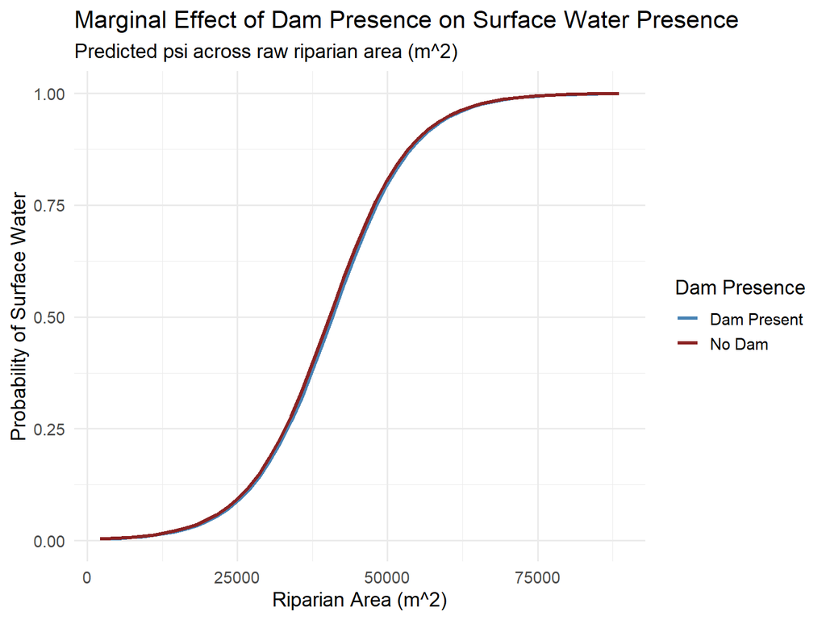

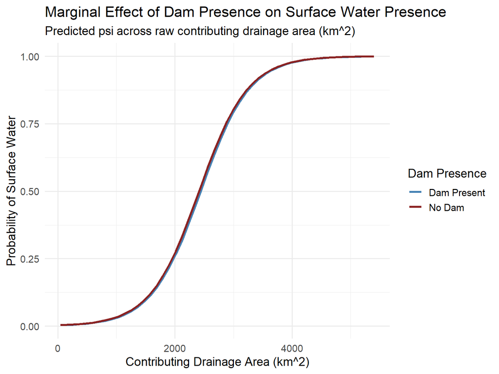

**Partial dependence plots**

Constrain PDP to empirical ranges for SWA and target covariates

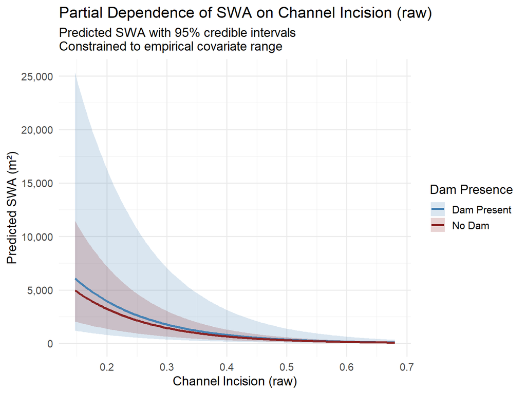

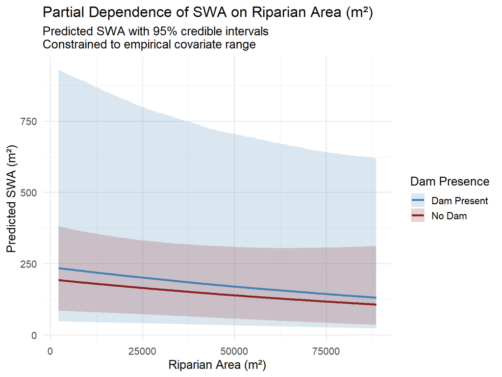

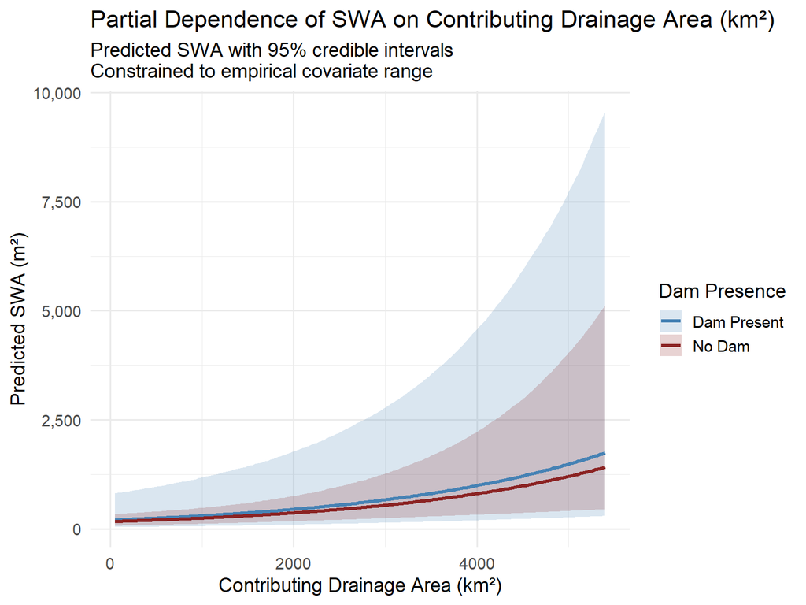

- heatmap
- line graph

## Dam Density

**Hurdle HGLMM**

```
sink("HGLMM_hurdle_damDensity.jags")

cat("
model{
  # NEED priors and hyperpriors first so that downstream nodes can be estimated

  ##########################################################################

  # HYPERPRIORS FOR SW PRESENCE (1/2 Normal on SDs):

  sigma_zeta_stream  ~ dnorm(0,1) T(0,)
  tau_zeta_stream    <- pow(sigma_zeta_stream, -2)

  sigma_zeta_year    ~ dnorm(0,1) T(0,)
  tau_zeta_year      <- pow(sigma_zeta_year, -2)

  sigma_zeta_event   ~ dnorm(0,1) T(0,)
  tau_zeta_event     <- pow(sigma_zeta_event, -2)

  sigma_iota_stream  ~ dnorm(0,1) T(0,)
  tau_iota_stream    <- pow(sigma_iota_stream, -2)

  sigma_iota_event   ~ dnorm(0,1) T(0,)
  tau_iota_event     <- pow(sigma_iota_event, -2)

  sigma_iota_cluster ~ dnorm(0,1) T(0,)
  tau_iota_cluster   <- pow(sigma_iota_cluster, -2)

  ##########################################################################
  # HYPERPRIORS FOR SW AMOUNT (1/2 Normal on SDs):

  sigma              ~ dnorm(0,1) T(0,)
  tau                <- pow(sigma, -2)

  sigma_beta_stream  ~ dnorm(0, 0.7) T(0,)
  tau_beta_stream    <- pow(sigma_beta_stream, -2)

  sigma_beta_year    ~ dnorm(0, 0.7) T(0,)
  tau_beta_year      <- pow(sigma_beta_year, -2)

  sigma_beta_event   ~ dnorm(0, 0.7) T(0,)
  tau_beta_event     <- pow(sigma_beta_event, -2)

  sigma_eta_stream   ~ dnorm(0, 1) T(0,)
  tau_eta_stream     <- pow(sigma_eta_stream, -2)

  sigma_eta_event    ~ dnorm(0, 1) T(0,)
  tau_eta_event      <- pow(sigma_eta_event, -2)

  sigma_eta_cluster  ~ dnorm(0, 1) T(0,)
  tau_eta_cluster    <- pow(sigma_eta_cluster, -2)

  ##########################################################################
  # FIXED EFFECT PRIORS:

  # Presence/absence:
  epsilon ~ dnorm(0,0.04)
  zeta_damDen ~ dnorm(0,0.04)
  zeta_incis ~ dnorm(0,0.04)
  zeta_RIPA ~ dnorm(0,0.04)
  zeta_UDA ~ dnorm(0,0.04)

  # Amount:
  alpha ~ dnorm(0,0.04)
  beta_damDen ~ dnorm(0,0.04)
  beta_incis ~ dnorm(0,0.04)
  beta_RIPA ~ dnorm(0,0.04)
  beta_UDA ~ dnorm(0,0.04)

  ##########################################################################
  # RANDOM EFFECT PRIORS FOR SW PRESENCE:

  for(j in 1:n_stream){
    zeta_stream[j] ~ dnorm(0, tau_zeta_stream)
    iota_stream[j] ~ dnorm(0, tau_iota_stream)
  }

  for(yr in 1:n_year){
    zeta_year[yr] ~ dnorm(0, tau_zeta_year)
  }

  for(k in 1:n_event){
    zeta_event[k] ~ dnorm(0, tau_zeta_event)
    iota_event[k] ~ dnorm(0, tau_iota_event)
  }

  for(c in 1:n_cluster){
    iota_cluster[c] ~ dnorm(0, tau_iota_cluster)
  }

  ##########################################################################
  # RANDOM EFFECT PRIORS FOR SW AMOUNT:

  for(j in 1:n_stream){
    beta_stream[j] ~ dnorm(0, tau_beta_stream)
    eta_stream[j]  ~ dnorm(0, tau_eta_stream)
  }

  for(yr in 1:n_year){
    beta_year[yr] ~ dnorm(0, tau_beta_year)
  }

  for(k in 1:n_event){
    beta_event[k] ~ dnorm(beta_year[event_year[k]], tau_beta_event)
    eta_event[k]  ~ dnorm(0, tau_eta_event)
  }

  for(c in 1:n_cluster){
    eta_cluster[c] ~ dnorm(0, tau_eta_cluster)
  }

  ##########################################################################
  # DETECTION PRIORS:

  for(k in 1:n_event){
  p_TP[k] ~ dnorm(0.76, pow(0.16,-2)) T(0,1)   # empirically derived recall
  p_FP[k] ~ dnorm(0.01, pow(0.005,-2)) T(0,1)  # empirically derived FPR
  }

  ##########################################################################
  # MAIN LOOP: PRESENCE, DETECTION, AMOUNT

  for(i in 1:N){

    # Presence/absence:
    z[i] ~ dbern(psi[i])

    logit(psi[i]) <- epsilon
                     + (zeta_damDen
                        + zeta_stream[stream[i]]
                        + zeta_year[year[i]]
                        + zeta_event[event[i]]) * damDen[i]
                     + zeta_incis * incis[i]
                     + zeta_RIPA * RIPA[i]
                     + zeta_UDA * UDA[i]
                     + iota_stream[stream[i]]
                     + iota_event[event[i]]
                     + iota_cluster[cluster[i]]

    # Detection:
    p_eff[i] <- z[i] * p_TP[event[i]] + (1-z[i]) * p_FP[event[i]]
    y[i]     ~ dbern(p_eff[i])

    # Amount:
    y2[i] ~ dnorm(mu[i], tau_eff[i])

    mu[i] <- z[i] *
              (alpha
                + (beta_damDen
                  + beta_stream[stream[i]]
                  + beta_year[year[i]]
                  + beta_event[event[i]]) * damDen[i]
                + beta_incis * incis[i]
                + beta_RIPA * RIPA[i]
                + beta_UDA * UDA[i]
                + eta_stream[stream[i]]
                + eta_event[event[i]]
                + eta_cluster[cluster[i]])

    tau_eff[i] <- z[i] * tau + (1 - z[i]) * 100
  }

}
", fill = TRUE)

sink()
```

```
## [1] "2026-07-24 14:16:51 MDT"
```

```
##
## Processing function input.......
##
## Done.
##
## Beginning parallel processing using 3 cores. Console output will be suppressed.
##
## Parallel processing completed.
##
## Calculating statistics.......
##
## Done.
```

```
## [1] "2026-07-24 14:56:37 MDT"
```

## DIAGNOSTICS:

**Assess “Chain health” Rhat + ESS:**

```
## Potential scale reduction factors:
##
##                    Point est. Upper C.I.
## epsilon                  1.00       1.00
## alpha                    1.00       1.00
## zeta_damDen              1.00       1.00
## beta_damDen              1.04       1.04
## zeta_incis               1.00       1.00
## beta_incis               1.00       1.00
## zeta_RIPA                1.00       1.00
## beta_RIPA                1.00       1.00
## zeta_UDA                 1.00       1.00
## beta_UDA                 1.00       1.00
## sigma                    1.00       1.00
## sigma_zeta_stream        1.00       1.00
## sigma_iota_cluster       1.00       1.00
## p_TP[1]                  1.00       1.00
## p_FP[1]                  1.00       1.00
```

```
##            epsilon              alpha        zeta_damDen        beta_damDen
##         42292.9599         48518.7278         36773.5233           965.5766
##         zeta_incis         beta_incis          zeta_RIPA          beta_RIPA
##         18318.3426         47105.2135         44588.0782         47313.1479
##           zeta_UDA           beta_UDA              sigma  sigma_zeta_stream
##         19084.4342         47473.4334         44637.8084         10836.3380
## sigma_iota_cluster            p_TP[1]            p_FP[1]
##          9068.7155         37572.1613         47357.1719
```

```
Good Rhat values, all around 1.00.

Mostly high effective sample sizes. Note: beta_damDen has the most trouble converging (unsurprising).
```

**Check traceplots** for critical parameters:

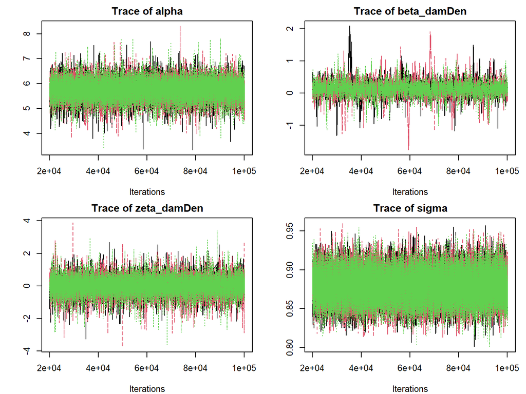

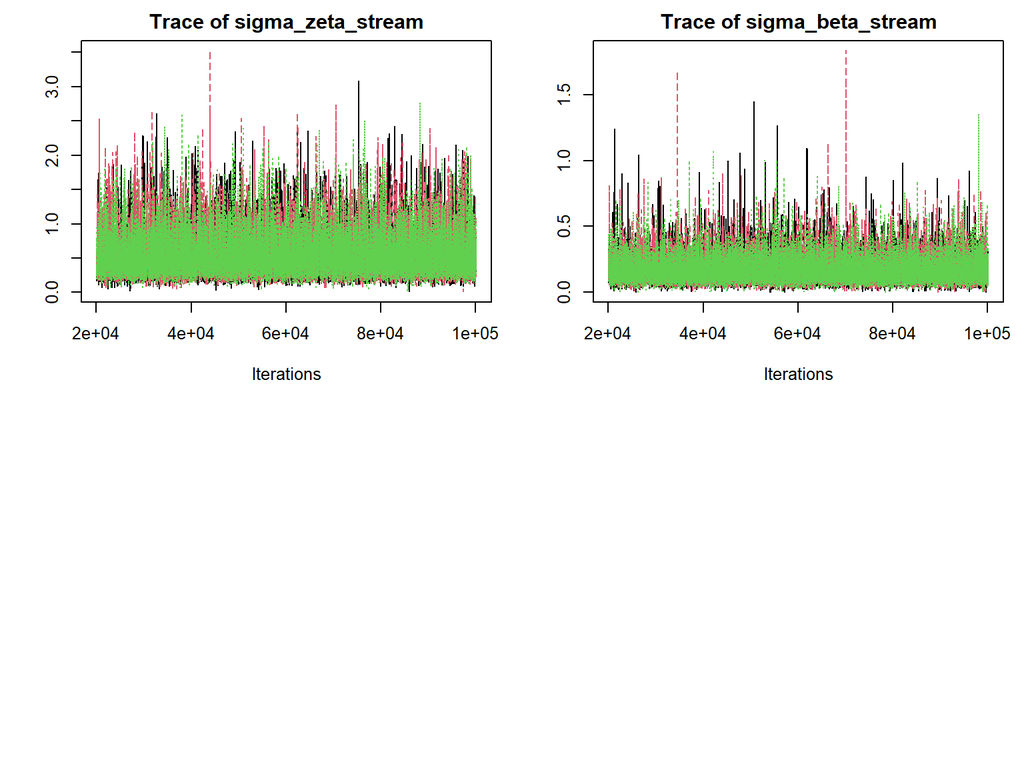

```
Traceplots all look good, except for beta_damDen, which is mostly grassy, but
slow to converge - suggesting that its difficult for the model to estimate.
```

**Posterior predictive plots:**

Predicted Psi vs observed SW presence

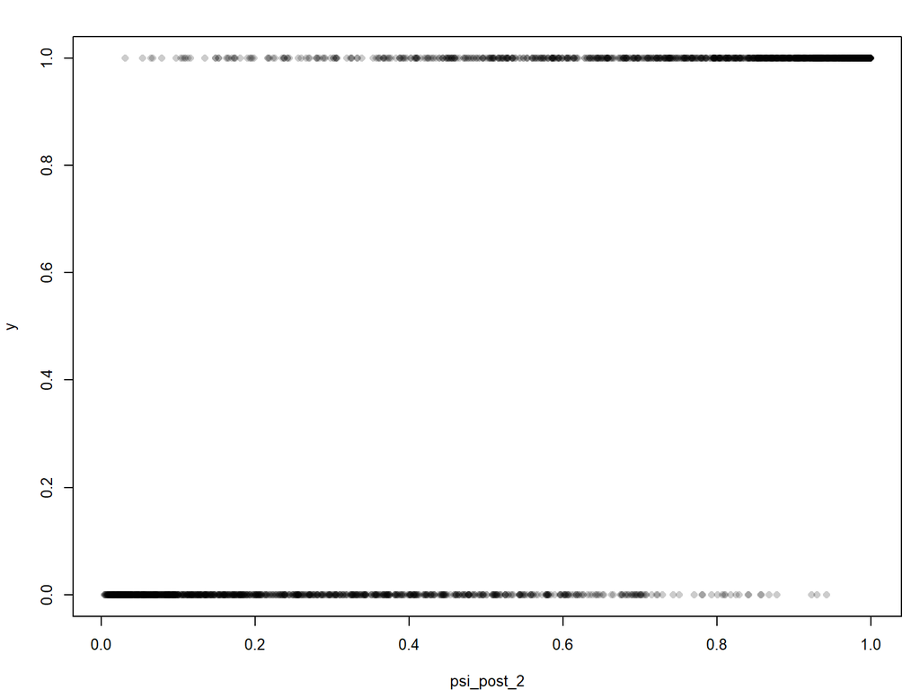

Predicted SW vs observed SW

Goal is 1:1 (ish)

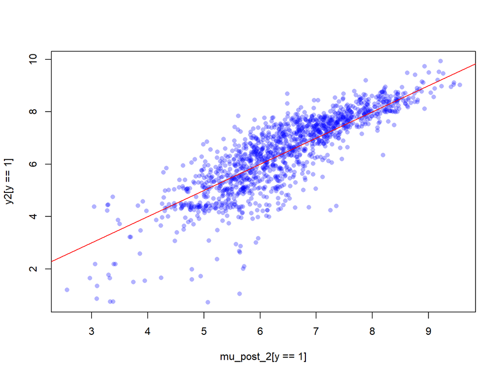

**Random effects shrinkage:**

Goal is centered around 0(ish)

1. zeta_stream; random effect of stream on sw presence
2. beta_stream; random effect of stream on sw amount
3. zeta_event; random effect of sample event on sw presence
4. beta_event; random effect of sample event on sw amount

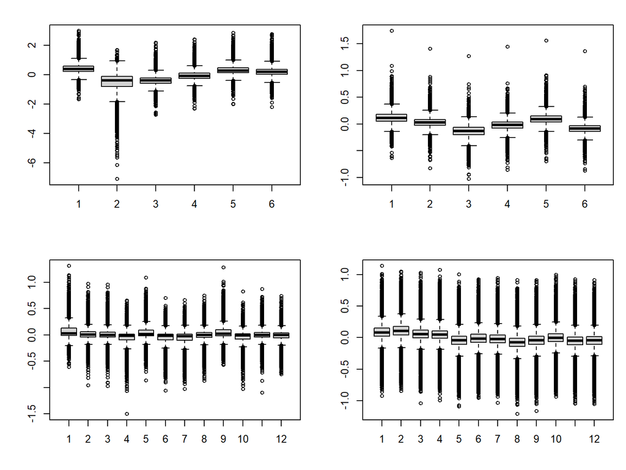

**Posterior mean dam effects:**

damDen –> swPres

```
##     Min.  1st Qu.   Median     Mean  3rd Qu.     Max.
## -3.74498 -0.20125  0.04639  0.03095  0.27551  3.87159
```

```
## [1] 1.03143
```

```
1 std dev. increase in dam density increases odds of surface water
presence by ~ 0.03. This corresponds to ~0.5 - 1 percentage-point increase
on the probability scale.

1 std dev. of dam density from raw data is about 3.14 dams

Massive overlap of 0. Really no major effect of 1 std dev increase in dam
density on surface water presence
```

damDen –> swAmount

```
##     Min.  1st Qu.   Median     Mean  3rd Qu.     Max.
## -1.76858  0.03003  0.14000  0.13868  0.24856  2.08949
```

```
## [1] 1.148754
```

[output not shown]

**Prior-posterior overlap:**

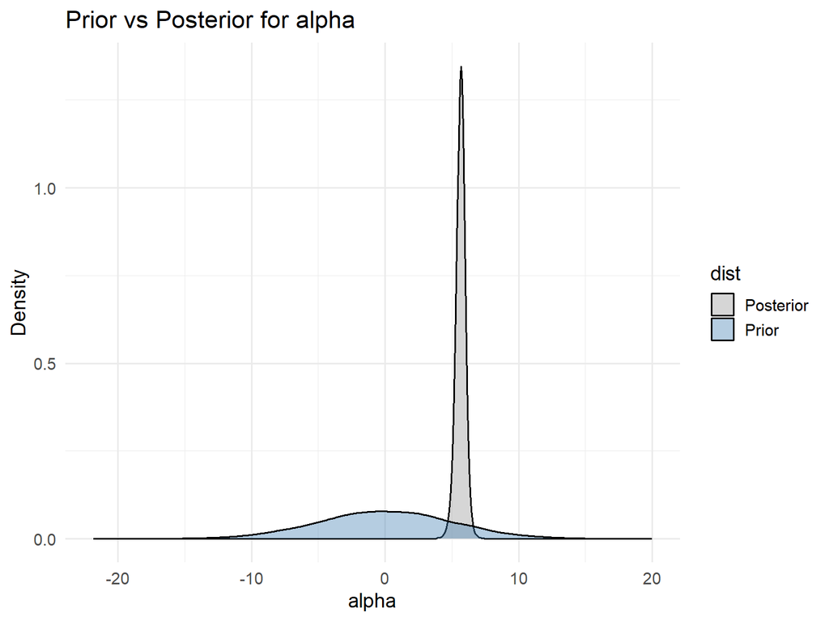

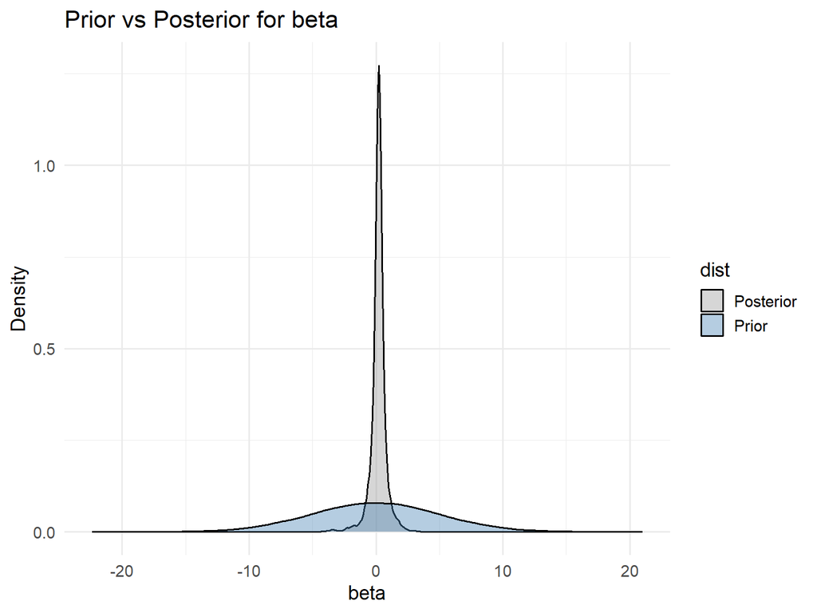

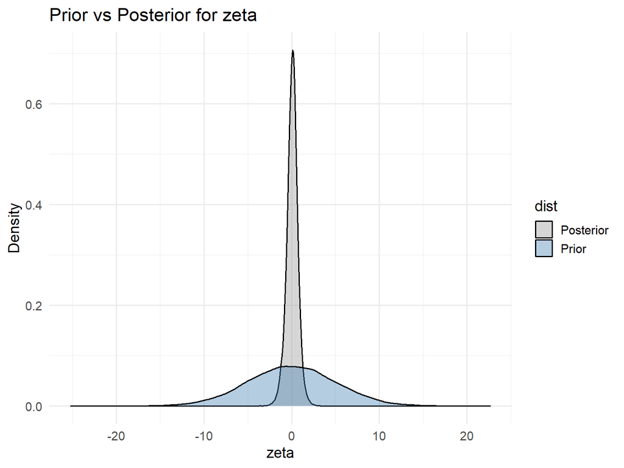

**Marginal effect** of dam Density on surface water presence, given geomorphic context